# Data Analysis with R - Wine Quality White by Michelle_Beckner

The dataset I choose to examine is white wine quality. White wine samples from variants of the Portuguese “Vinho Verde” wine were evaluated by wine experts. The dataset consists of 11 inputs and one output. The inputs are the following:

1 - fixed acidity 2 - volatile acidity 3 - citric acid 4 - residual sugar 5 - chlorides 6 - free sulfur dioxide 7 - total sulfur dioxide 8 - density 9 - pH 10 - sulfates 11 - alcohol

There was 1 output. The output was quality as measured with a score from 1 t0 10 by the wine experts.

P. Cortez, A. Cerdeira, F. Almeida, T. Matos and J. Reis. Modeling wine preferences by data mining from physicochemical properties. In Decision Support Systems, Elsevier, 47(4):547-553. ISSN: 0167-9236.

Available at: [@Elsevier] http://dx.doi.org/10.1016/j.dss.2009.05.016 [Pre-press (pdf)] http://www3.dsi.uminho.pt/pcortez/ winequality09.pdf [bib] http://www3.dsi.uminho.pt/pcortez/dss09.bib

Univariate Plots Section

```
## [1] "data.frame"
```

The data is organized into a data frame.

```
## [1] 4898   13
```

The data frame has 4898 rows and 13 columns.

```
## 'data.frame':    4898 obs. of  13 variables:
##  $ X                   : int  1 2 3 4 5 6 7 8 9 10 ...
##  $ fixed.acidity       : num  7 6.3 8.1 7.2 7.2 8.1 6.2 7 6.3 8.1 ...
##  $ volatile.acidity    : num  0.27 0.3 0.28 0.23 0.23 0.28 0.32 0.27 0.3 0.22 ...
##  $ citric.acid         : num  0.36 0.34 0.4 0.32 0.32 0.4 0.16 0.36 0.34 0.43 ...
##  $ residual.sugar      : num  20.7 1.6 6.9 8.5 8.5 6.9 7 20.7 1.6 1.5 ...
##  $ chlorides           : num  0.045 0.049 0.05 0.058 0.058 0.05 0.045 0.045 0.049 0.044 ...
##  $ free.sulfur.dioxide : num  45 14 30 47 47 30 30 45 14 28 ...
##  $ total.sulfur.dioxide: num  170 132 97 186 186 97 136 170 132 129 ...
##  $ density             : num  1.001 0.994 0.995 0.996 0.996 ...
##  $ pH                  : num  3 3.3 3.26 3.19 3.19 3.26 3.18 3 3.3 3.22 ...
##  $ sulphates           : num  0.45 0.49 0.44 0.4 0.4 0.44 0.47 0.45 0.49 0.45 ...
##  $ alcohol             : num  8.8 9.5 10.1 9.9 9.9 10.1 9.6 8.8 9.5 11 ...
##  $ quality             : int  6 6 6 6 6 6 6 6 6 6 ...
```

The above chart summarizes what I already found out with the data is in a data frame, has 4898 rows and 13 columns. I also see the column names and that the columns are made up of integers and numeric (decimals).

```
##   X fixed.acidity volatile.acidity citric.acid residual.sugar chlorides
## 1 1           7.0             0.27        0.36           20.7     0.045
## 2 2           6.3             0.30        0.34            1.6     0.049
## 3 3           8.1             0.28        0.40            6.9     0.050
## 4 4           7.2             0.23        0.32            8.5     0.058
## 5 5           7.2             0.23        0.32            8.5     0.058
## 6 6           8.1             0.28        0.40            6.9     0.050
##   free.sulfur.dioxide total.sulfur.dioxide density   pH sulphates alcohol
## 1                  45                  170  1.0010 3.00      0.45     8.8
## 2                  14                  132  0.9940 3.30      0.49     9.5
## 3                  30                   97  0.9951 3.26      0.44    10.1
## 4                  47                  186  0.9956 3.19      0.40     9.9
## 5                  47                  186  0.9956 3.19      0.40     9.9
## 6                  30                   97  0.9951 3.26      0.44    10.1
##   quality
## 1       6
## 2       6
## 3       6
## 4       6
## 5       6
## 6       6
```

The first row consists of column names. Each row represents the information for one sample of white wine.

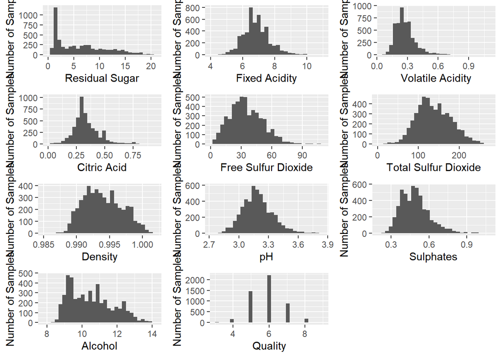

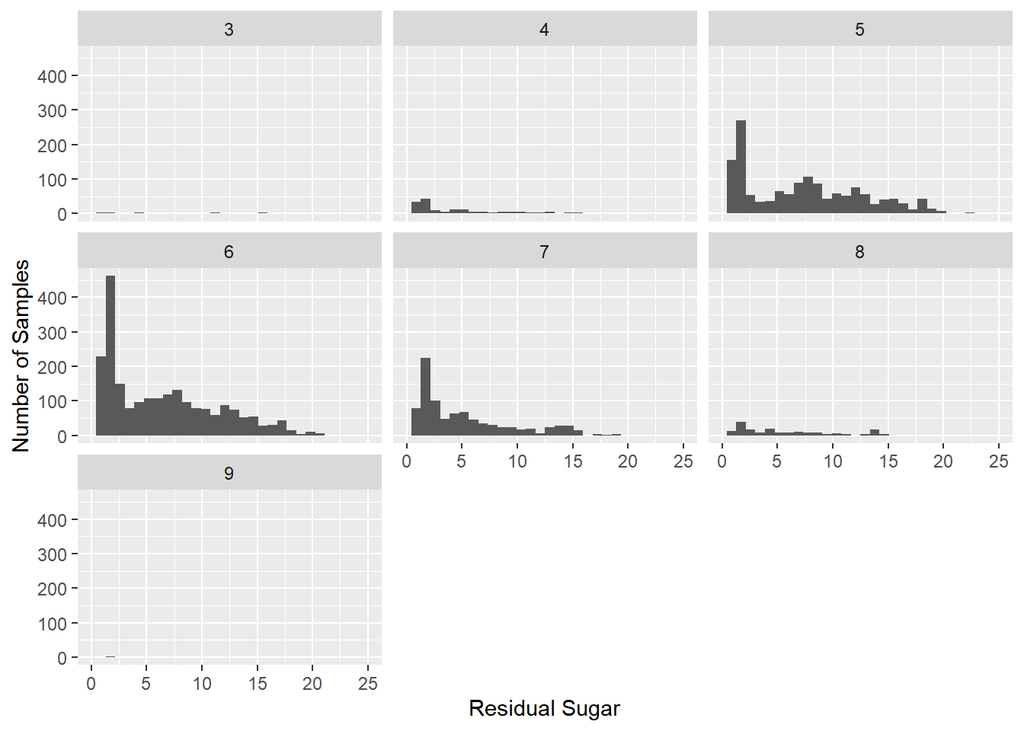

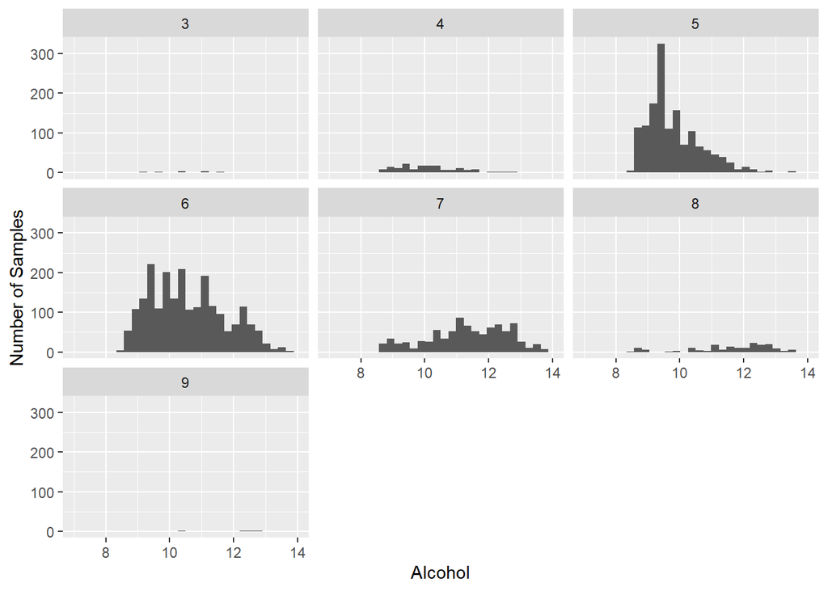

The above charts show the alcohol content broken out by the different quality ratings.

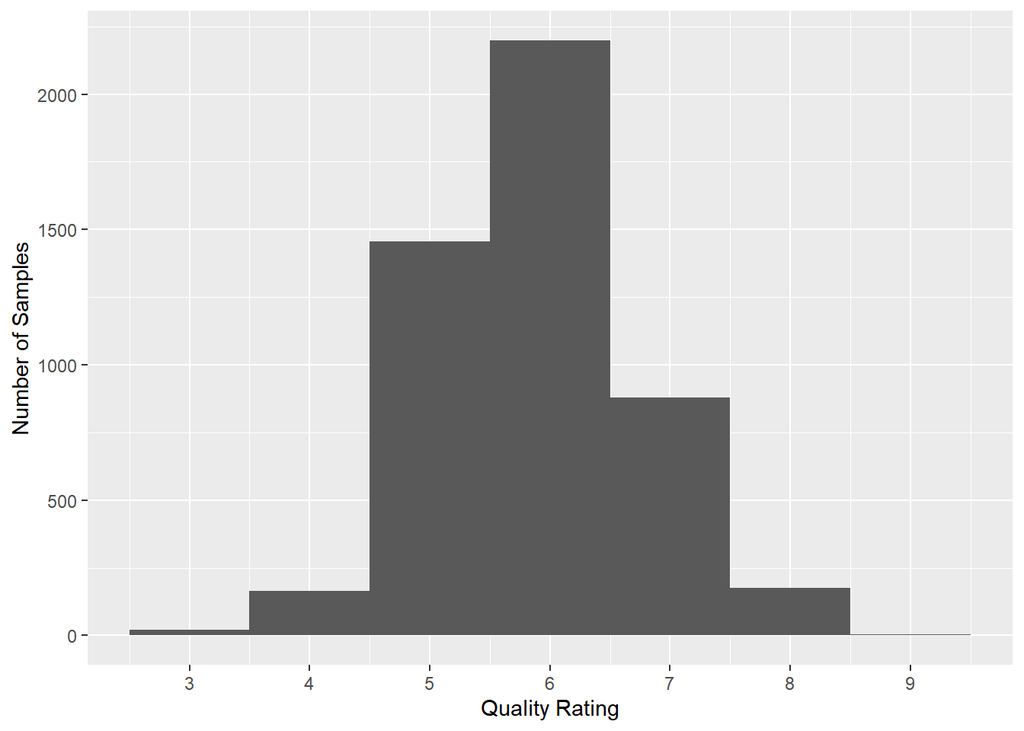

The wine quality was rated from 1 - 10 with the rating of 6 being given the most. There was no sample that received a 1 or a 10 rating.

```
##
##    3    4    5    6    7    8    9
##   20  163 1457 2198  880  175    5
```

The above table shows how many samples were rated in each quality category.

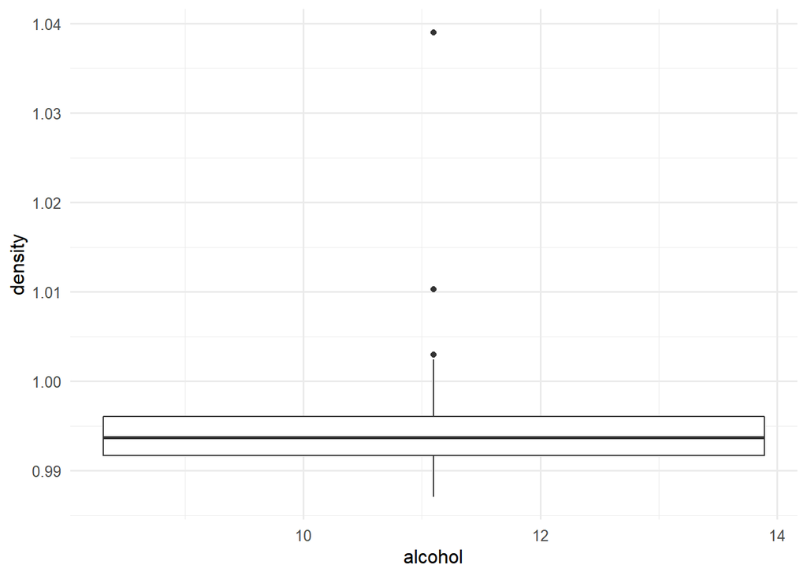

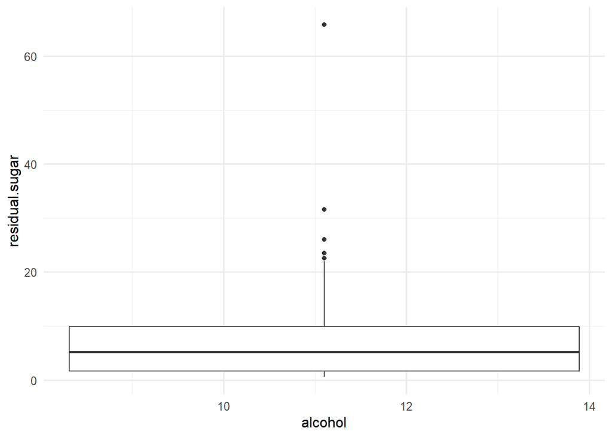

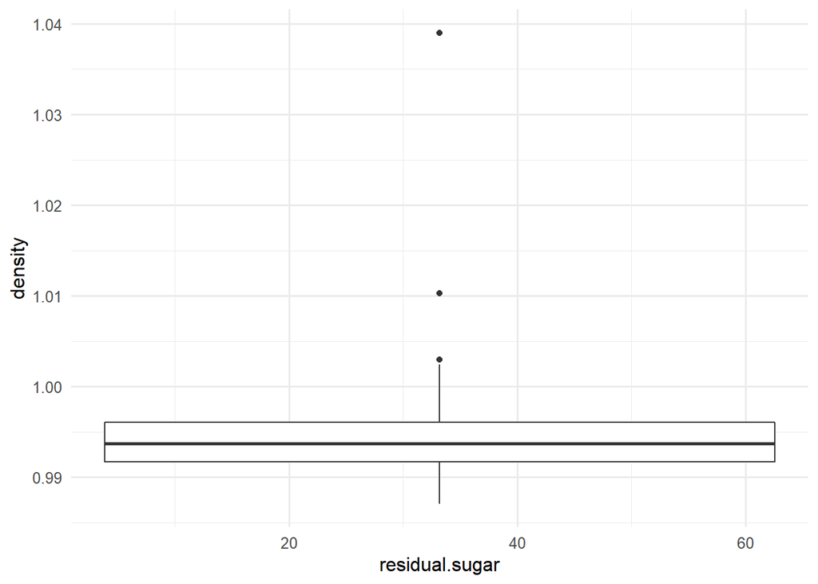

The above 3 box charts just shows some more relationships between the 3 variables that I have been looking at: alcohol, density and residual sugar.

# Bivariate Plots Section

I want to see if there is correlation between alcohol content and density.

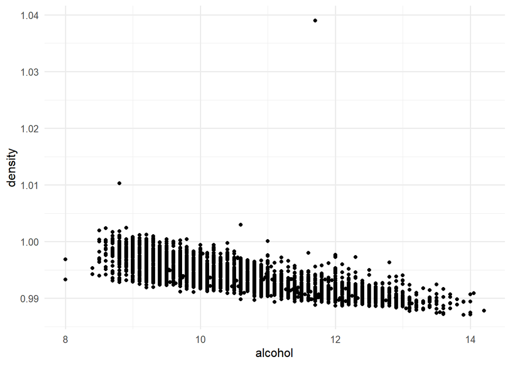

From the above chart, it shows that the lower the alcohol content is the lower the higher the density.

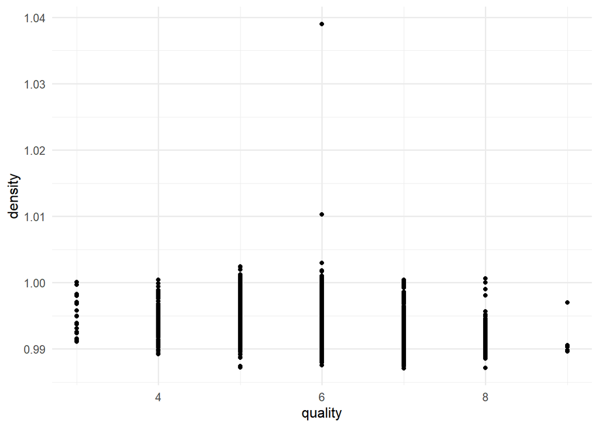

This chart appears to show the the higher quality scores have lower density. Although I do not think this is the best chart type to reflect that.

```
##
##  Pearson's product-moment correlation
##
## data:  wqw$alcohol and wqw$density
## t = -87.255, df = 4896, p-value < 2.2e-16
## alternative hypothesis: true correlation is not equal to 0
## 95 percent confidence interval:
##  -0.7908646 -0.7689315
## sample estimates:
##        cor
## -0.7801376
```

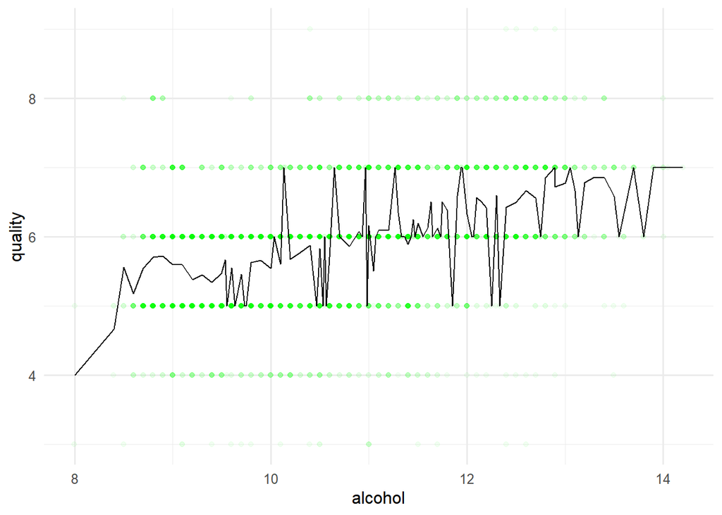

The above graph shows quality compared to alcohol content. The mean is also represented. It appears that the higher the alcohol content the higher rating the wine sample tended to receive.

```
##
##  Pearson's product-moment correlation
##
## data:  wqw$alcohol and wqw$quality
## t = 33.858, df = 4896, p-value < 2.2e-16
## alternative hypothesis: true correlation is not equal to 0
## 95 percent confidence interval:
##  0.4126015 0.4579941
## sample estimates:
##       cor
## 0.4355747
```

The pearson score of 0.43 shows there is a correlation between alcohol and quality. However, it’s not a real strong one.

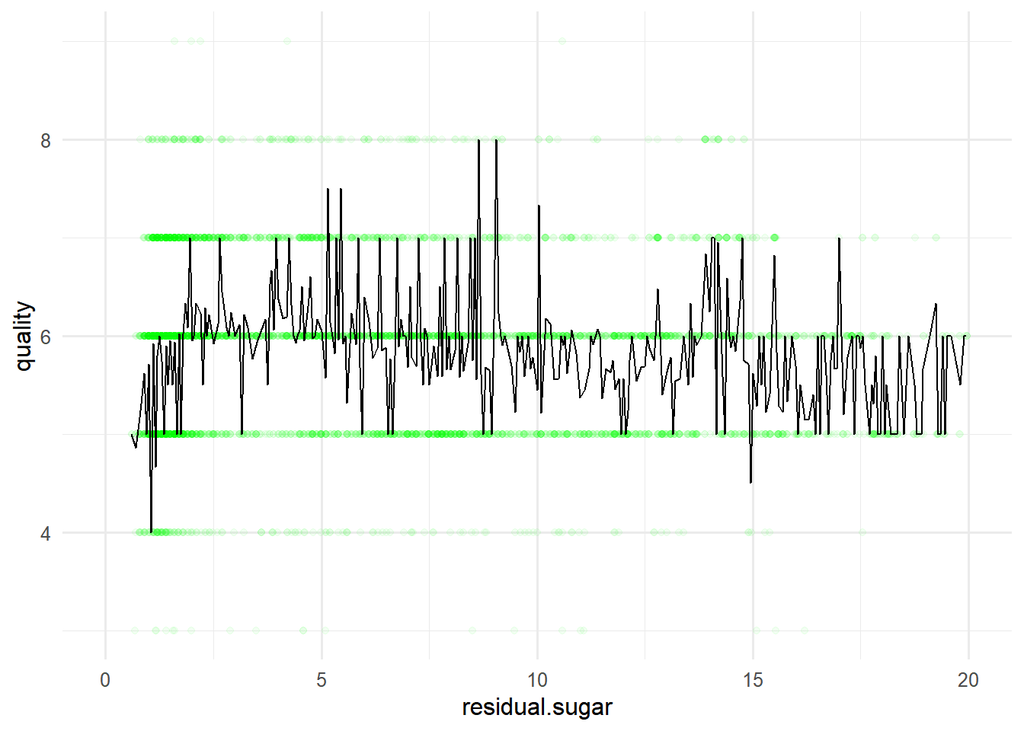

The above chart shows a quality ratings with the residual sugar content of the samples. It appears that there is a small correlation between the amount of residual sugar and the quality ratings of the samples. I will do a pearson test to see if this is correct.

```
##
##  Pearson's product-moment correlation
##
## data:  wqw$residual.sugar and wqw$quality
## t = -6.8603, df = 4896, p-value = 7.724e-12
## alternative hypothesis: true correlation is not equal to 0
## 95 percent confidence interval:
##  -0.12524103 -0.06976101
## sample estimates:
##         cor
## -0.09757683
```

# Multivariate Plots Section

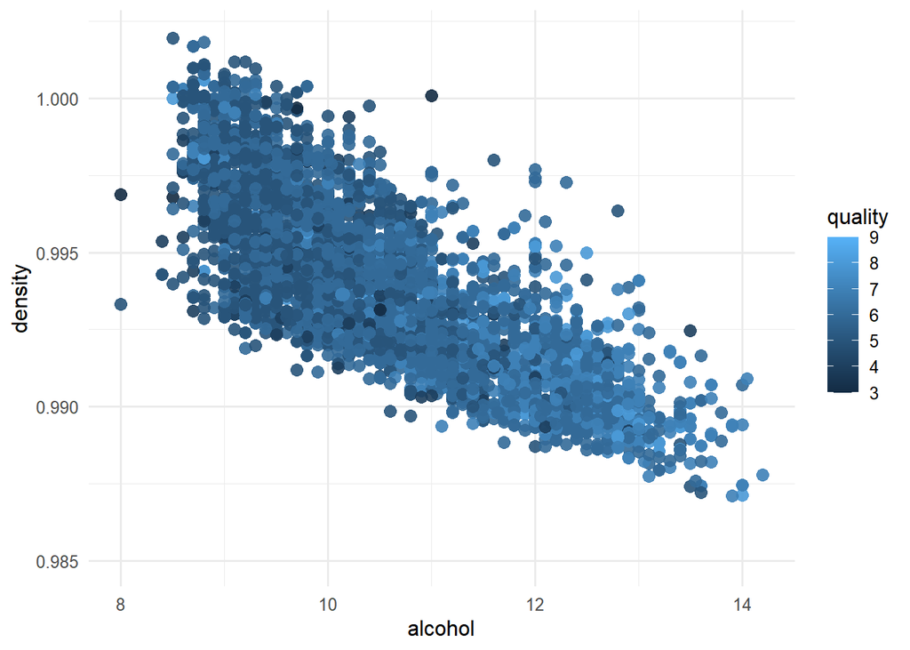

The above chart shows the density and alcohol comparison by adding the quality rating as well. The brighter the color, the higher the quality rating. This shows that the higher alcohol content not only has the lower density but higher rating. This shows what we have been seeing that the higher the alcohol content, the lower the density and the higher the quality rating.

# Final Plots and Summary

### Plot One

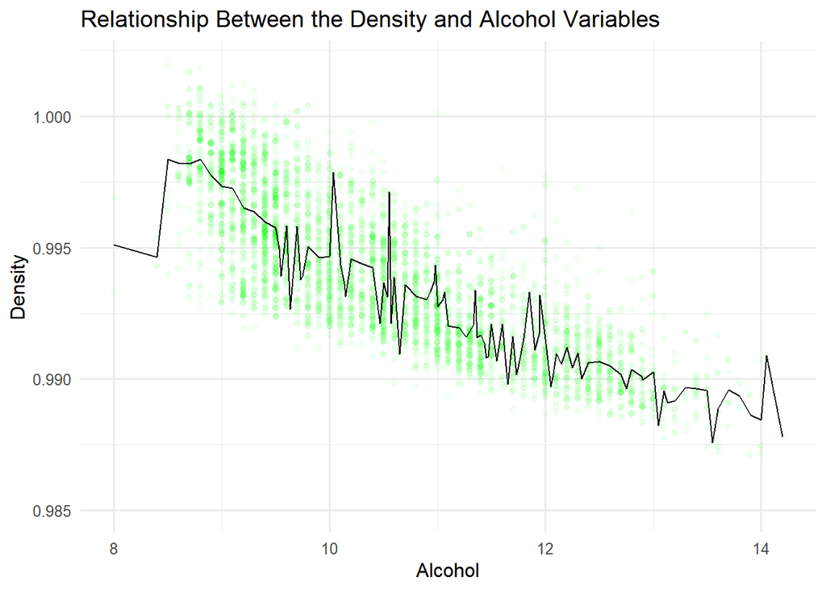

### Description One

The above chart shows the density variable compared to the alcohol variable that was explored above. The density mean was added for extra clarification. The chart further shows that the higher the density the lower the alcohol content.

### Plot Two

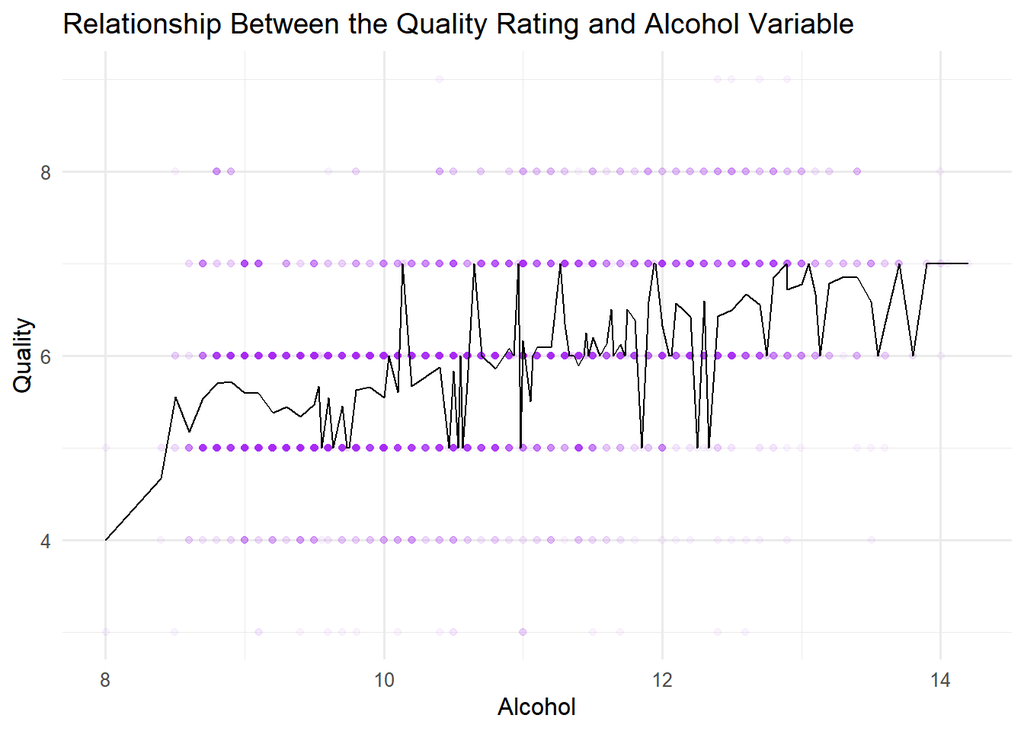

The above graph shows quality compared to alcohol content. The mean is also represented. It appears that the higher the alcohol content the higher rating the wine sample tended to receive.

### Plot Three

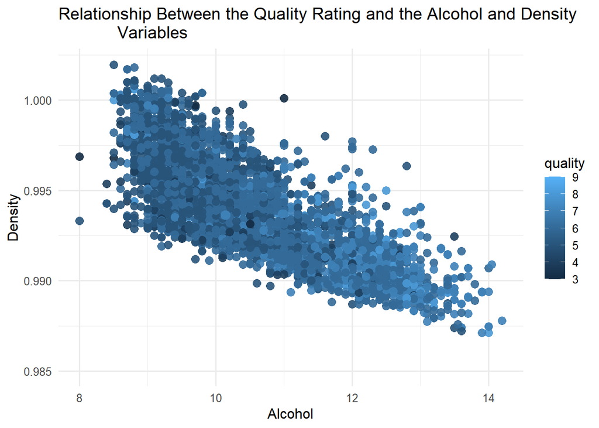

The above brings all three factors together - alcohol content, density and quality rating. The brighter the color, the higher the quality rating. This shows that the higher alcohol content not only has the lower density but higher rating. This shows what we have been seeing that the higher the alcohol content, the lower the density and the higher the quality rating. ——

# Reflection

This was an interesting look at wine and the different variables that go into different wines. It wasn’t a surprise that the higher the alcohol content corresponded with the higher quality ratings. What did surprise me was that the residual sugar had no real impact on the quality ratings. I also was not expecting the density to play a factor. However, these charts show that the higher rated wines had lower density.

#Resources

N/A.